```python
import sys
sys.path.insert(0, '/Users/johanneswidera/Uni/bachelorarbeit/Code/models/')
```

```python
from sklearn.model_selection import train_test_split
import numpy as np
import shap
import pandas as pd
import numpy as np
from sklearn import linear_model
from bs4 import BeautifulSoup
import os
import contractions
import re
import string
from helper import read_imdb_split,download_data
from model_helper.tf_idf import build_tf_idf
from model_helper.PipelineWrapper import PipelineWrapper
from custom_shap_explainer.custom_global import custom_global_explanation
from custom_shap_explainer.signal_words import highlight_signal_words
np.random.seed(1337)
shap.initjs()
```

[output not shown]

[output cut: 13 more lines]

# 1. Get Training Data

```python
download_data()
corpus_train, y_train = read_imdb_split('../data/aclImdb/train')
corpus_test, y_test = read_imdb_split('../data/aclImdb/test')
```

```
The input looks more like a filename than markup. You may want to open this file and pass the filehandle into Beautiful Soup.
```

# 2. Build Vectorizer

```python
vectorizer_tf_idf = build_tf_idf()
vectorizer_tf_idf.fit(corpus_train)
```

```
TfidfVectorizer(max_df=0.99, min_df=0.001)
```

# 3. Build Models

# 3.1 Build Logistic Regression Model

```python
model = linear_model.LogisticRegression(penalty="l2")
model_logregression_new = PipelineWrapper(model, vectorizer_tf_idf, corpus_test, corpus_train, y_test, y_train)
```

```python
model_logregression_new.fit()
```

```
<model_helper.PipelineWrapper.PipelineWrapper at 0x177b85d60>
```

```python
model_logregression_new.report()
```

|  | 0 | 1 | accuracy | macro avg | weighted avg |
| --- | --- | --- | --- | --- | --- |
| precision | 0.885746 | 0.886735 | 0.88624 | 0.886241 | 0.886241 |
| recall | 0.886880 | 0.885600 | 0.88624 | 0.886240 | 0.886240 |
| f1-score | 0.886313 | 0.886167 | 0.88624 | 0.886240 | 0.886240 |
| support | 12500.000000 | 12500.000000 | 0.88624 | 25000.000000 | 25000.000000 |

```python
predictions_logreg = model_logregression_new.predict_proba(corpus_test)


LOGREG_PREDICTION_FILE = 'predictions_logreg.csv'

file_exists = os.path.exists(LOGREG_PREDICTION_FILE)

if not file_exists:
    # Calculate BERT predictions

    predictions_logreg = model_logregression_new.predict_proba(corpus_test)

# Destructure probabilities for class_1 and class_2
    predictions_class_0 = predictions_logreg[:, 0]
    predictions_class_1 = predictions_logreg[:, 1]

    # Create a DataFrame containing the test samples and BERT predictions
    results = pd.DataFrame({
    'logreg_0': predictions_class_0,
    'logreg_1': predictions_class_1
    })
    # Create a DataFrame containing the test samples and BERT predictions

    # Save the DataFrame to a CSV file
    results.to_csv(LOGREG_PREDICTION_FILE)
```

# 3.2 Build Decision Tree Classifier

```python
from sklearn.tree import DecisionTreeClassifier


model_dtc = PipelineWrapper(DecisionTreeClassifier(min_samples_leaf=20), vectorizer_tf_idf, corpus_test, corpus_train, y_test, y_train)
```

```python
model_dtc.fit()
```

```
<model_helper.PipelineWrapper.PipelineWrapper at 0x178068310>
```

```python
model_dtc.report()
```

|  | 0 | 1 | accuracy | macro avg | weighted avg |
| --- | --- | --- | --- | --- | --- |
| precision | 0.713115 | 0.728629 | 0.7206 | 0.720872 | 0.720872 |
| recall | 0.738160 | 0.703040 | 0.7206 | 0.720600 | 0.720600 |
| f1-score | 0.725422 | 0.715606 | 0.7206 | 0.720514 | 0.720514 |
| support | 12500.000000 | 12500.000000 | 0.7206 | 25000.000000 | 25000.000000 |

```python
predictions_DTC = model_dtc.predict_proba(corpus_test[:1])
predictions_DTC
```

```
array([[0.73913043, 0.26086957]])
```

```python
DTC_PREDICTION_FILE = 'predictions_dtc.csv'

file_exists = os.path.exists(DTC_PREDICTION_FILE)

if not file_exists:
    # Calculate DTC predictions
    predictions_DTC = model_dtc.predict_proba(corpus_test)

# Destructure probabilities for class_1 and class_2
    predictions_class_0 = predictions_DTC[:, 0]
    predictions_class_1 = predictions_DTC[:, 1]

    # Create a DataFrame containing the test samples and BERT predictions
    results = pd.DataFrame({
    'dtc_0': predictions_class_0,
    'dtc_1': predictions_class_1
    })
    results.to_csv(DTC_PREDICTION_FILE)
```

# 3.3 Build Fine Tuned BERT

```python
from transformers import AutoTokenizer, AutoModelForSequenceClassification
from transformers import pipeline

# Load tokenizer
tokenizer = AutoTokenizer.from_pretrained("../../FineTunedBERT/Sentiment/24060142")
# Load model
loaded_model = AutoModelForSequenceClassification.from_pretrained("../../FineTunedBERT/Sentiment/24060142")
model_bert = pipeline('sentiment-analysis', model=loaded_model, tokenizer=tokenizer, max_length=512, truncation=True, top_k=None)
```

```python
model_bert.predict(corpus_test[:5])
```

```
[[{'label': 'LABEL_1', 'score': 0.9973391890525818},
  {'label': 'LABEL_0', 'score': 0.0026607937179505825}],
 [{'label': 'LABEL_1', 'score': 0.9945743680000305},
  {'label': 'LABEL_0', 'score': 0.005425640847533941}],
 [{'label': 'LABEL_0', 'score': 0.9939568042755127},
  {'label': 'LABEL_1', 'score': 0.006043117959052324}],
 [{'label': 'LABEL_0', 'score': 0.9993140697479248},
  {'label': 'LABEL_1', 'score': 0.0006858850247226655}],
 [{'label': 'LABEL_0', 'score': 0.9995158910751343},
  {'label': 'LABEL_1', 'score': 0.0004840875626541674}]]
```

```python
BERT_PREDICTION_FILE = 'prediction_BERT.csv'

file_exists = os.path.exists(BERT_PREDICTION_FILE)

if not file_exists:
    # Calculate BERT predictions
    raw_predictions_bert = model_bert.predict(corpus_test)

    # Destructure probabilities for class_1 and class_2
    predictions_class_0 = [pred[0]['score'] if pred[0]['label'] == 'LABEL_0' else pred[1]['score'] for pred in raw_predictions_bert]
    predictions_class_1 = [pred[0]['score'] if pred[0]['label'] == 'LABEL_1' else pred[1]['score'] for pred in raw_predictions_bert]

    # Create a DataFrame containing the test samples and BERT predictions
    results = pd.DataFrame({
        'bert_0': predictions_class_0,
        'bert_1': predictions_class_1
    })

    # Save the DataFrame to a CSV file
    results.to_csv(BERT_PREDICTION_FILE)
```

# 3.4 load all prediciton in one dataframe

so we can see which sample is most interesting

```python
from Sentiment.disagreements import get_disagreements

dtc_bert_sorted_by_diff,logreg_bert_sorted_by_diff,logreg_dtc_sorted_by_diff = get_disagreements(y_test,BERT_PREDICTION_FILE, LOGREG_PREDICTION_FILE, DTC_PREDICTION_FILE)

# Wähle die Top-N interessanten Samples
top_n = 3
```

```python
dtc_bert_sorted_by_diff.head(top_n)
```

|  | bert_0 | bert_1 | logreg_0 | logreg_1 | dtc_0 | dtc_1 | label | logreg_dtc_diff | logreg_bert_diff | dtc_bert_diff |
| --- | --- | --- | --- | --- | --- | --- | --- | --- | --- | --- |
| 11488 | 0.999520 | 0.000480 | 0.981925 | 0.018075 | 0.0 | 1.0 | 0 | 0.981925 | 0.017595 | 0.999520 |
| 1356 | 0.999511 | 0.000489 | 0.933107 | 0.066893 | 0.0 | 1.0 | 0 | 0.933107 | 0.066405 | 0.999511 |
| 16722 | 0.999500 | 0.000500 | 0.959625 | 0.040375 | 0.0 | 1.0 | 0 | 0.959625 | 0.039875 | 0.999500 |

```python
logreg_bert_sorted_by_diff.head(top_n)
```

|  | bert_0 | bert_1 | logreg_0 | logreg_1 | dtc_0 | dtc_1 | label | logreg_dtc_diff | logreg_bert_diff | dtc_bert_diff |
| --- | --- | --- | --- | --- | --- | --- | --- | --- | --- | --- |
| 7153 | 0.004288 | 0.995712 | 0.943614 | 0.056386 | 0.541667 | 0.458333 | 1 | 0.401947 | 0.939326 | 0.537378 |
| 16340 | 0.998061 | 0.001939 | 0.058830 | 0.941170 | 0.523810 | 0.476190 | 1 | 0.464979 | 0.939231 | 0.474251 |
| 9634 | 0.047879 | 0.952121 | 0.981160 | 0.018840 | 1.000000 | 0.000000 | 1 | 0.018840 | 0.933281 | 0.952121 |

```python
logreg_dtc_sorted_by_diff.head(top_n)
```

|  | bert_0 | bert_1 | logreg_0 | logreg_1 | dtc_0 | dtc_1 | label | logreg_dtc_diff | logreg_bert_diff | dtc_bert_diff |
| --- | --- | --- | --- | --- | --- | --- | --- | --- | --- | --- |
| 3399 | 0.999370 | 0.000630 | 0.990490 | 0.009510 | 0.0 | 1.0 | 0 | 0.990490 | 0.008880 | 0.999370 |
| 4503 | 0.999444 | 0.000556 | 0.988408 | 0.011592 | 0.0 | 1.0 | 0 | 0.988408 | 0.011036 | 0.999444 |
| 12221 | 0.000841 | 0.999159 | 0.014658 | 0.985342 | 1.0 | 0.0 | 1 | 0.985342 | 0.013817 | 0.999159 |

# 4 Analyze With SHAP

We know that the Logistic Regression Performs better than the Decision Tree Classifier. To further investigate why thats the case we need to look into the models.

In the following i will do 3 things.

Per Model:

1. Most Positive/Negative Words
2. Investigate the Most Wrong Positive and Negative prediction

Model Comparision:

1. Investigate biggest Prediction gap accross the models

# 4.1 Logistic Regression with SHAP

```python
masker = shap.maskers.Text(tokenizer=r"\W+") # this will create a basic whitespace tokenizer
# explainer_logreg = shap.Explainer(model_logregression_new.predict_proba , masker)
explainer_logreg = shap.Explainer(model_logregression_new.predict_proba, masker)
#shap_values_logreg = explainer_logreg(corpus_test)
```

```python
# Performance Optimazation

import os.path
import pickle

shap_values_file = "shap_values_logreg.pkl"

# Überprüfen, ob die Datei existiert
if not os.path.exists(shap_values_file):
    # Berechnen Sie die SHAP-Werte, wenn die Datei nicht existiert
    shap_values_logreg = explainer_logreg(corpus_test)

    # Speichern Sie die SHAP-Werte in einer Datei
    with open(shap_values_file, "wb") as f:
        pickle.dump(shap_values_logreg, f)
else:
    # Laden Sie die SHAP-Werte aus der Datei, wenn sie existiert
    with open(shap_values_file, "rb") as f:
        shap_values_logreg = pickle.load(f)
```

### 4.1 Investigate the biggest misclassification

```python
from Sentiment.disagreements import get_misclassifications
logreg_misclassifications = get_misclassifications(y_test,LOGREG_PREDICTION_FILE)
```

```python
logreg_misclassifications[:5]
```

|  | logreg_0 | logreg_1 | label | diff |
| --- | --- | --- | --- | --- |
| 8426 | 0.015421 | 0.984579 | 0 | 0.984579 |
| 8989 | 0.016913 | 0.983087 | 0 | 0.983087 |
| 9634 | 0.981160 | 0.018840 | 1 | 0.981160 |
| 18328 | 0.980439 | 0.019561 | 1 | 0.980439 |
| 6685 | 0.021349 | 0.978651 | 0 | 0.978651 |

```python
# Really good example to investigate why the model predicted the wrong class
most_wrong_positive_index  = 9634
```

#### 4.1.2 Most Wrong Positive Classification

Most wrong review

```python
print(logreg_misclassifications.loc[most_wrong_positive_index])
print(corpus_test[most_wrong_positive_index])
```

```
logreg_0    0.98116
logreg_1    0.01884
label       1.00000
diff        0.98116
Name: 9634, dtype: float64
when the movie first started i thought cheesy the first ten minutes were really boring after the slow beginning and some of the soap opera antics i started liking it the plot was different than anything i had ever seen now was it a horror not really it should not have been classied as a horror or th…
```

```python
explanation = shap_values_logreg[most_wrong_positive_index, :, 1]
```

[figure not shown]

inputs

when the

movie first

started i

thought cheesy

the first

ten

minutes

were really

boring

after

the slow beginning and

some of the soap

opera antics i started

liking it the plot

was different than anything

i had

ever seen

now was

it

a

horror not really it

should not

have been

classied as a horror or

the

producers

should

have

put more

money

into

the movie to make it scary as it

was

the

creatures where

only

there

for a

short

time

i can

only

assume

this

was

for

money

reason

the

good

side

was

that

the movie

was very

entertaining

it

held my

interest

after

the

start

and

did

make

me

wonder

about creatures from another

dimension it was obvious

that this

was a

first time

movie for

the director

but

there

were

a

couple

of highlights

by

the

end i

was hooked

too

bad

hollywood did

not put

more

money

behind this

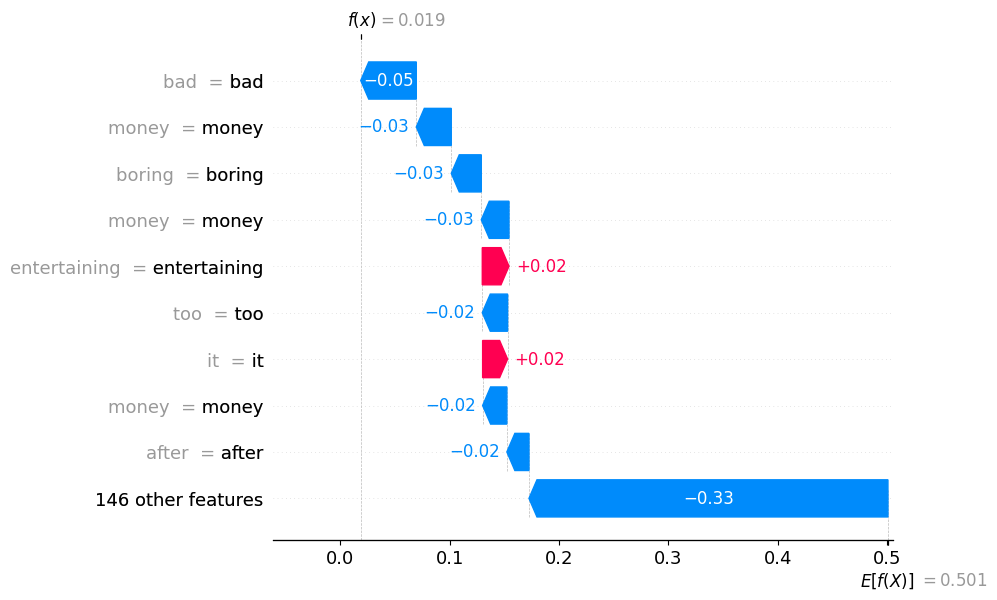

```python
shap.plots.text(explanation)
shap.plots.waterfall(explanation)
```

```python
# further investigate what words really matter - highlight the words that contributed most to the prediction

highlight_signal_words(explanation,round_shap_values=3,top_words=4)
```

when the movie first started i thought cheesy the first ten minutes were really

boring -0.027

after -0.02

the slow beginning and some of the soap opera antics i started liking it the plot was different than anything i had ever seen now was it a horror not really it should not have been classied as a horror or the producers should have put more

money -0.025

into the movie to make it scary as it was the creatures where only there for a short time i can only assume this was for

money -0.032

reason -0.02

the

good 0.013

side was that the movie was very

entertaining 0.024

it 0.023

held 0.01

my 0.01

interest after the start

and 0.01

did make me wonder about creatures from another dimension it was obvious that this was a first time movie for the director but there were a couple of highlights by the end i

was 0.009

hooked 0.009

too -0.023

bad -0.051

hollywood did not put more

money -0.022

behind this

# interpretation:

The model learned that the word bad and boring are negative sentiment words and they overlap all other words you can see that the review is really positive beacuse of this passage: `after the slow beginning and some of the soap opera antics i started liking it the plot was different than anything i had ever seen now`.

So it wasnt able to understand that the word liking is really important for the sentiment.

With the highlight Plot we can really see that it doesnt pay relevant attention to the relevant part.

#### 4.1.2 Most Wrong Negative Classification

Most wrong review

```python
most_wrong_negative_index  = 8426
explanation = shap_values_logreg[most_wrong_negative_index, :, 1]
```

```python
print(logreg_misclassifications.loc[most_wrong_negative_index])
print(corpus_test[most_wrong_negative_index])
```

```
logreg_0    0.015421
logreg_1    0.984579
label       0.000000
diff        0.984579
Name: 8426, dtype: float64
this movie was pure genius john waters is brilliant it is hilarious and i am not sick of it even after seeing it about 20 times since i bought it a few months ago the acting is great although ricki lake could have been better and johnny depp is magnificent he is such a beautiful man and a very talen…
```

[figure not shown]

inputs

this

movie

was pure

genius

john

waters

is

brilliant

it

is

hilarious

and

i

am

not

sick

of

it

even

after

seeing

it

about

20

times

since

i

bought

it

a

few

months

ago the acting is

great

although

ricki lake

could

have

been

better

and

johnny

depp

is

magnificent

he is such a

beautiful

man

and

a very talented actor and

seeing

most

of johnny

s movies this is

probably

my

favorite

i

give it

9

5

10 rent

it

today

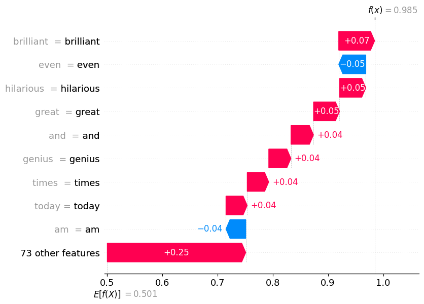

```python
shap.plots.text(explanation)
shap.plots.waterfall(explanation)
```

```python
highlight_signal_words(explanation,round_shap_values=3,top_words=4)
```

this movie was pure genius john waters is

brilliant 0.065

it is

hilarious 0.048

and 0.041

i

am -0.036

not -0.031

sick of it

even -0.049

after seeing it about 20 times since i bought it a few months ago the acting is

great 0.047

although ricki lake

could -0.014

have

been -0.014

better -0.014

and johnny depp is magnificent he is such a beautiful man and a very talented actor and seeing most of johnny s movies this is probably my favorite i give it 9 5 10 rent it today

# Interpretation:

This was a correct classification but the initial label is wrong? So we found a mistake in the labeled training data. With this information we can remove the sample and further improve the training process

# 4.2 Global Interpretation Most Positive and negative Words

To understand how the model works

```
Creating an ndarray from ragged nested sequences (which is a list-or-tuple of lists-or-tuples-or ndarrays with different lengths or shapes) is deprecated. If you meant to do this, you must specify 'dtype=object' when creating the ndarray.
```

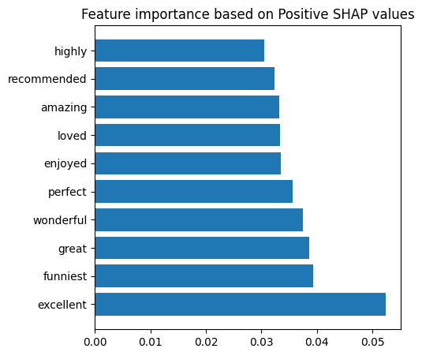

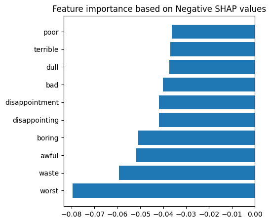

```python
custom_global_explanation(shap_values_logreg[:,:,1])
```

# interpretation:

It seems like the model learned the correct words

# 5. Analyze with SHAP: DTC

```python
masker = shap.maskers.Text(tokenizer=r"\W+") # this will create a basic whitespace tokenizer
# explainer_logreg = shap.Explainer(model_logregression_new.predict_proba , masker)
explainer_dtc = shap.Explainer(model_dtc.predict_proba, masker)
```

```python
import os.path
import pickle

shap_values_file = "shap_values_dtc.pkl"

# Überprüfen, ob die Datei existiert
if not os.path.exists(shap_values_file):
    # Berechnen Sie die SHAP-Werte, wenn die Datei nicht existiert
    shap_values_dtc= explainer_dtc(corpus_test)

    # Speichern Sie die SHAP-Werte in einer Datei
    with open(shap_values_file, "wb") as f:
        pickle.dump(shap_values_dtc, f)
else:
    # Laden Sie die SHAP-Werte aus der Datei, wenn sie existiert
    with open(shap_values_file, "rb") as f:
        shap_values_dtc = pickle.load(f)
```

```
Partition explainer: 25001it [1:31:53,  4.52it/s]
```

# 5.1 Investigate Biggest Misclasssifications

```python
dtc_misclassifications = get_misclassifications(y_test, DTC_PREDICTION_FILE)
```

```python
dtc_misclassifications[:5]
```

|  | dtc_0 | dtc_1 | label | diff |
| --- | --- | --- | --- | --- |
| 11488 | 0.0 | 1.0 | 0 | 1.0 |
| 11617 | 1.0 | 0.0 | 1 | 1.0 |
| 11461 | 0.0 | 1.0 | 0 | 1.0 |
| 3690 | 0.0 | 1.0 | 0 | 1.0 |
| 21724 | 0.0 | 1.0 | 0 | 1.0 |

```python
most_wrong_positive_index = 11617
```

### 5.2.1 Most Wrong Positive Classification

```python
explanation = shap_values_dtc[most_wrong_positive_index, :, 1]
print(dtc_misclassifications.loc[most_wrong_positive_index])
print(corpus_test[most_wrong_positive_index])
```

```
dtc_0    1.0
dtc_1    0.0
label    1.0
diff     1.0
Name: 11617, dtype: float64
this is one peace of art if you like comedy you should watch this here comes a funny moment from the movie spoiler nikolai and goroshkov are walking together in paris for the first time they are visiting the local market and goroshkov goes look nikolai how much food they have look one two three ten …
```

```python
model_dtc.predict_proba([corpus_test[most_wrong_positive_index]])
```

```
array([[1., 0.]])
```

[output not shown]

[figure not shown]

inputs

this is one peace

of art if you

like comedy you should

watch this here comes

a

funny

moment

from

the movie spoiler nikolai and

goroshkov

are

walking together

in paris

for

the

first

time

they are

visiting the local market

and

goroshkov

goes

look

nikolai

how

much

food they

have look

one

two

three ten thirty fifty

hundred kinds of meat

but

if ask for a

tiny tiny

peace just

for the taste they

will not give you

french are very greedy

then goroshkov takes nikolai

to a tv shop goroshkov tell me who

needs all these televisions

look at

this

monster

here for example goroshkov points a finger at the monster tv

and goes

and

this motherfu ker he is supposed to be

digging a ditch but

no

he

is on

tv wait a minute

that is me hahah want to laugh watch

the

movie

you

will

not

regret

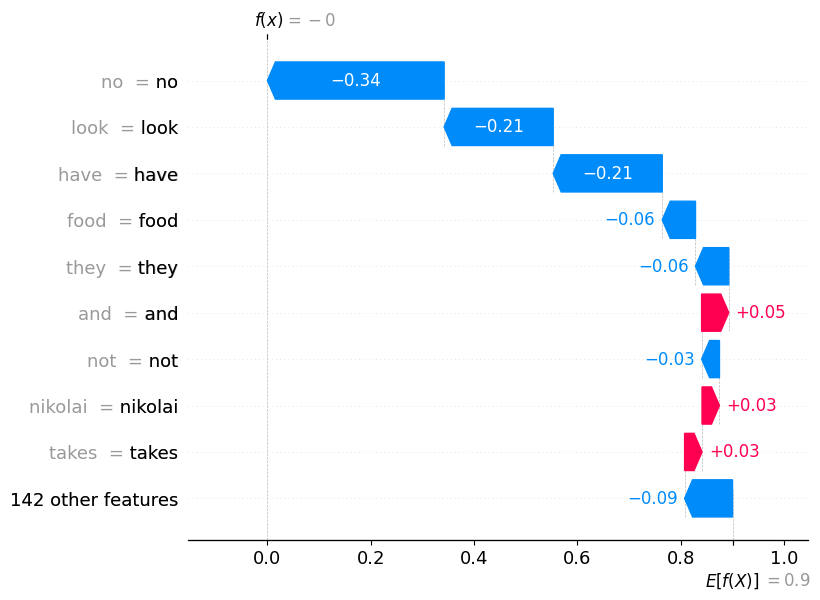

```python
print(explanation.base_values)
shap.plots.text(explanation)
shap.plots.waterfall(explanation)
```

```python
highlight_signal_words(explanation,round_shap_values=3,top_words=4)
```

this is one peace of art if you like comedy you should watch this here comes a funny moment from the movie spoiler nikolai and goroshkov are walking together in paris for the first time

they -0.022

are -0.022

visiting the local market and goroshkov goes look nikolai how much

food -0.064

they -0.064

have -0.211

look -0.211

one two three ten thirty fifty hundred kinds of meat but if ask for a tiny tiny peace just for the taste they will not give you french are very greedy

then 0.034

goroshkov 0.034

takes 0.034

nikolai 0.034

to a tv shop goroshkov tell me who needs all these televisions

look -0.022

at -0.022

this monster here for example goroshkov points a finger at the monster tv

and 0.034

goes 0.034

and 0.053

this motherfu ker he is supposed to be digging a ditch but

no -0.342

he is on tv wait a minute that is me hahah want to laugh watch the movie you will

not -0.035

regret

### interpretation

if you read it you know This is a positive Review. This Classifier Fails to understand that the review is talking about the scene and not about the movie you can clearly see the dominating words food they have look are all understand as negative words have great impact on the result with Shap values up to -0.2

### 5.2.2 Most Wrong Negative Classification

```python
most_wrong_negative_index = 11488
explanation = shap_values_dtc[most_wrong_negative_index, :, 1]
print(dtc_misclassifications.loc[most_wrong_negative_index])
print(corpus_test[most_wrong_negative_index])
```

```
dtc_0    0.0
dtc_1    1.0
label    0.0
diff     1.0
Name: 11488, dtype: float64
it seems to be a common thing in the 90 s to play with cliches some manage to do so with great talent hervé hadmar does not on the paper the movie looked interesting though the weak plot could have been saved by great moments of comedy dark humour and a very décalé style director hadmar unfortunatel…
```

[figure not shown]

inputs

it seems

to be

a common

thing in

the 90

s

to

play with

cliches some

manage

to

do

so

with

great

talent hervé

hadmar

does

not on

the

paper

the movie

looked

interesting

though

the

weak plot

could

have

been saved

by

great

moments

of

comedy

dark

humour

and

a

very

décalé

style

director

hadmar

unfortunately

kills

his direction with his

camera angles and

his

absolute

lack

of

rhythm

every

joke

is

embarassing

as

no

one

reacts in

the

theater

the

movie

is incredibly

slow

and

the actors

seem to

be wondering

what

the

hell

they

are

doing

in

this

ridiculous

mascarade

what could

have

been

a

stylish

funny

mindless

comedy

ends

up being

a

cathedral

of boredom

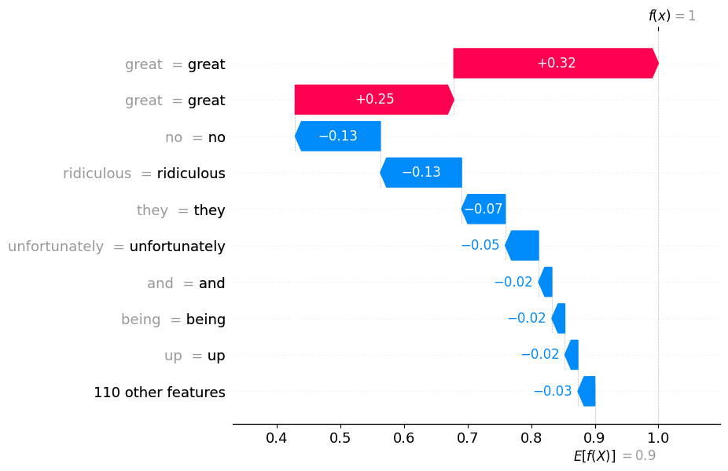

it seems to be a common thing in the 90 s to play with cliches some manage to do so with

great 0.25

talent hervé hadmar does not on the paper the movie looked interesting though the weak plot could have been saved by

great 0.322

moments of comedy dark humour

and -0.021

a very décalé style

director 0.01

hadmar

unfortunately -0.052

kills his direction with his camera angles and his

absolute 0.016

lack of

rhythm 0.008

every joke is embarassing as

no -0.134

one reacts in the theater the movie is incredibly slow and the actors seem to be wondering what the hell

they -0.069

are doing in this

ridiculous -0.128

mascarade what could have been a stylish funny mindless comedy ends up being a cathedral of boredom

```python
shap.plots.text(explanation)
shap.plots.waterfall(explanation)
highlight_signal_words(explanation,round_shap_values=3,top_words=4)
```

#### Interpretation

This is clearly a negative review this person hates the movie. What confused the model was the use of great it was used in respect of the talent of the actor and what could have saved the movie: "great momments of comedy dark humour". But both uses of great wasnt about the movie.

# 5.3 Global Explanation

```
Creating an ndarray from ragged nested sequences (which is a list-or-tuple of lists-or-tuples-or ndarrays with different lengths or shapes) is deprecated. If you meant to do this, you must specify 'dtype=object' when creating the ndarray.
```

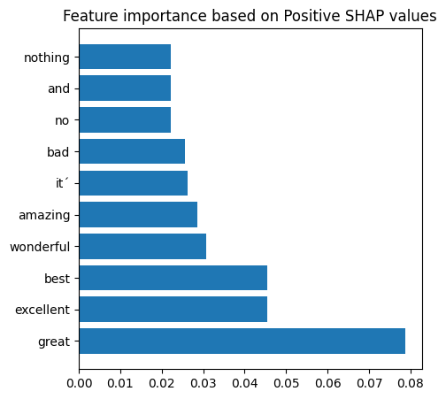

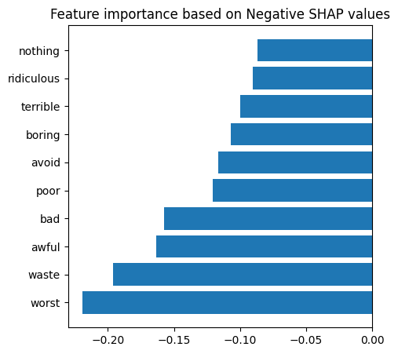

```python
custom_global_explanation(shap_values_dtc[:,:,1])
```

```python
custom_global_explanation(shap_values_dtc[:,:,1])
```

# 6 SHAP for BERT

```python
"""

In summary, the reason your code is not using the GPU is that the SHAP library does not support GPU acceleration for BERT models. Unfortunately, there is no direct solution to this issue. You can try looking for alternative libraries or methods that support GPU acceleration for BERT or similar text models.
 """

# Performance Optimazation
masker = shap.maskers.Text(tokenizer=r"\W+") # this will create a basic whitespace tokenizer
# explainer_logreg = shap.Explainer(model_logregression_new.predict_proba , masker)
explainer_bert = shap.Explainer(model_bert, masker)
import os.path
import pickle

shap_values_file = "shap_values_bert.pkl"

# Überprüfen, ob die Datei existiert
if not os.path.exists(shap_values_file):
    # Berechnen Sie die SHAP-Werte, wenn die Datei nicht existiert
    shap_values_bert= explainer_bert(corpus_test[:100])

    # Speichern Sie die SHAP-Werte in einer Datei
    with open(shap_values_file, "wb") as f:
        pickle.dump(shap_values_bert, f)
else:
    # Laden Sie die SHAP-Werte aus der Datei, wenn sie existiert
    with open(shap_values_file, "rb") as f:
        shap_values_bert = pickle.load(f)
```

```
Partition explainer: 101it [24:30, 14.70s/it]
```

```python
shap_values_bert.shape
```

[output not shown]

# 6.1 Investigate Biggest Misclassifications

```python
dtc_misclassifications = get_misclassifications(y_test, BERT_PREDICTION_FILE)
dtc_misclassifications[:10]
```

|  | bert_0 | bert_1 | label | diff |
| --- | --- | --- | --- | --- |
| 19396 | 0.999469 | 0.000531 | 1 | 0.999469 |
| 22638 | 0.999456 | 0.000544 | 1 | 0.999456 |
| 12843 | 0.999410 | 0.000590 | 1 | 0.999410 |
| 23047 | 0.999383 | 0.000617 | 1 | 0.999383 |
| 3556 | 0.000622 | 0.999378 | 0 | 0.999378 |
| 3893 | 0.999377 | 0.000623 | 1 | 0.999377 |
| 18639 | 0.000631 | 0.999368 | 0 | 0.999368 |
| 19614 | 0.999361 | 0.000639 | 1 | 0.999361 |
| 22417 | 0.999358 | 0.000642 | 1 | 0.999358 |
| 18923 | 0.999354 | 0.000646 | 1 | 0.999354 |

### 6.1.2 Biggest Positive Misclassification

```python
most_wrong_positive_index = 19396

explanation = explainer_bert([corpus_test[most_wrong_positive_index]])
explanation = explanation[0, :, 1]
```

```
Partition explainer: 2it [00:12, 12.68s/it]
```

```
bert_0    0.999469
bert_1    0.000531
label     1.000000
diff      0.999469
Name: 19396, dtype: float64
this was laurel and hardy s last silent film for roach studios however since the public had a real thirst for talkies this same short was re made by the team just a few years later with only a few small plot changes laughing gravy was essentially the same plot except that stan and ollie were trying …
```

[figure not shown]

inputs

this was

laurel

and

hardy s

last

silent

film for

roach studios

however since the public had a real thirst

for talkies

this same

short was

re made

by the

team just

a few

years

later

with

only

a few

small

plot

changes laughing

gravy was

essentially the

same plot

except that stan

and

ollie were

trying to

hide a cute puppy

from their grouchy landlord

not a goat like

in angora

love this

whole

goat

angle is

the

worst

part of

the film

while you

could

understand

the

boys

wanting

to

keep a

cute little

dog after

all it

is

snowy

outside why

exactly they

bring a

goat home

is just

contrived

and

pointless

according

to the

plot the

goat followed

them home and

so they

got

tired

of shooing it away

and

kept

it

huh

this

just does

not

make

any

sense

if it

had been

a giraffe

or

a

cow

would

they

have

done

the

same

thing apart from being an unconvincing plot the movie itself is pure laurel

and

hardy

with

a

familiar

plot

and familiar roles for the comedians this film features quite a few laughs but

unfortunately

is

not

one

of their

better films

to wrap up their

silent careers

this aspect

of

their

careers

just

seems to

have ended

with

a

whimper

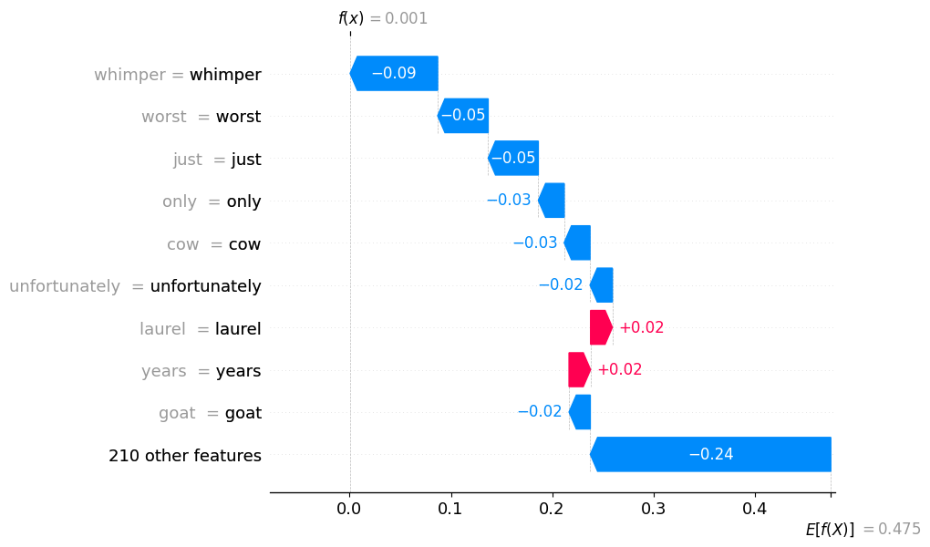

```python
print(dtc_misclassifications.loc[most_wrong_positive_index])
print(corpus_test[most_wrong_positive_index])
shap.plots.text(explanation)
shap.plots.waterfall(explanation)
```

```python
highlight_signal_words(explanation,round_shap_values=3,top_words=4)
```

this was

laurel 0.022

and hardy s last silent film for roach studios however since the public had a real thirst for talkies this same short was re made by the team just a few

years 0.021

later 0.011

with

only -0.026

a few

small -0.02

plot changes laughing gravy was essentially the same plot except that stan and ollie were trying to hide a cute puppy from their grouchy landlord not a goat like in angora love this whole

goat -0.021

angle is the

worst -0.05

part of the film while you could

understand 0.014

the boys wanting to keep a cute little dog after all it is

snowy 0.009

outside why exactly they bring a goat home is just contrived and pointless according to the plot the goat followed them home and so they got tired of shooing it away and kept it huh this just does not make any sense if it had been a giraffe or a

cow -0.026

would they have done the same thing apart from being an unconvincing plot the movie itself is pure laurel

and 0.011

hardy 0.014

with 0.009

a 0.01

familiar 0.018

plot and familiar roles for the comedians this film features quite a few laughs but

unfortunately -0.022

is

not -0.02

one of their better films to wrap up their silent careers this aspect of their

careers 0.009

just -0.05

seems to have ended with a

whimper -0.086

#### Interpretration

This Classification was correct the overall sentiment of the review is negative. But it sounds like this was a disappointed fan who is disappointed how the last laurel and hardy movie ended. Nevertheless its resulted in a review with a score of > 7. This could be fixed in the original dataset.

### 6.1.2 Biggest Negative Misclassification

```python
most_wrong_negative_index = 3556

explanation = explainer_bert([corpus_test[most_wrong_negative_index]])
explanation = explanation[0, :, 1]
```

```
Partition explainer: 2it [00:13, 13.62s/it]
```

```
bert_0    0.000622
bert_1    0.999378
label     0.000000
diff      0.999378
Name: 3556, dtype: float64
lois weber s film hypocrites was and still kind of is a very bold and daring film i enjoyed it and was very impressed by the filming and story of it the priest sees the hypocrisy of the people in his church and tries to show them the naked truth the people are appalled when he reveals the naked stat…
```

[figure not shown]

inputs

lois weber s film hypocrites was and

still kind

of is

a very

bold

and

daring film

i enjoyed

it

and

was very

impressed by

the filming

and

story of it the priest sees the hypocrisy of the people in his church and

tries to

show them

the naked truth the

people are

appalled when

he reveals the naked

statue portraying

truth after

failing to

lead them

to it and

the few that did help along the way the people do not want to face the

truth that

they are

doing anything wrong but

it shows them putting

things before god going

to beach

parties acting

inappropriate their materialistic ways

and

other things

in

which

the

people

of our

world

do

that tend

to not

be

morally

right in

the end

failing

to

gain

any

followers he

must enter

into the

gates of

heaven

alone

this film

seems to me to

be very bold in the fact that a

naked woman is shown

throughout it

especially considering

the time period in which this film was

made the imagery

and

symbolism portrayed

in this

movie i

found

incredible

the

way

they made

the naked woman translucent

and

using a naked woman

to symbolize the naked

truth shows

a lot

of creativity

and

art showing

the different

sins of the people

as they walked down

the road and

refused

to

follow

along

the path each with

different excuses

setbacks

and or

higher priorities was a

great

way

of representing

the people

of today

this film does a

very

good

job of

getting the

moral message

across to

its audience

lois weber has a

tremendous way

of capturing

her spectators

attention with

her creativity symbolism visuals

and

through

auditory

even

the

music

of

the

piano

throughout this

film is

very beautiful

and

fitting with

the whole

theme

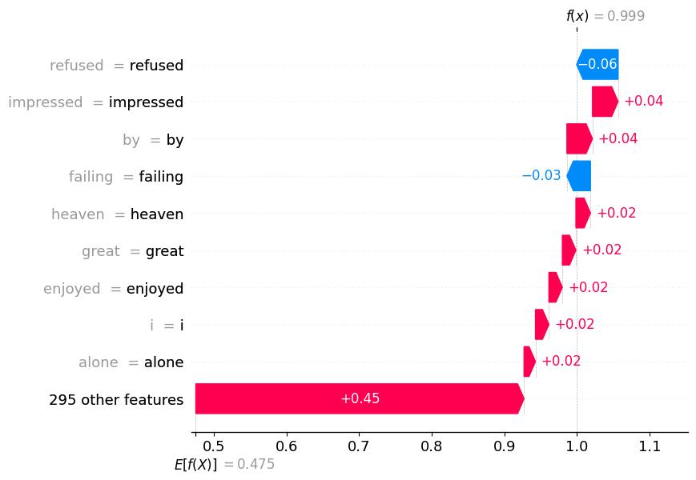

```python
print(dtc_misclassifications.loc[most_wrong_negative_index])
print(corpus_test[most_wrong_negative_index])
shap.plots.text(explanation)
shap.plots.waterfall(explanation)
```

```python
highlight_signal_words(explanation,round_shap_values=3,top_words=4)
```

lois weber s film hypocrites was and still kind of is a very bold

and 0.01

daring film

i 0.019

enjoyed 0.019

it and was very

impressed 0.035

by 0.035

the filming and story of it the priest sees the hypocrisy of the people in his church and

tries -0.005

to -0.005

show them the naked truth the people are appalled when he reveals the naked statue portraying truth after

failing -0.008

to -0.008

lead them to it and the few that did help along the way the people do not want to face the truth that they are doing anything wrong but it shows them putting things before god going to beach parties acting

inappropriate -0.012

their -0.012

materialistic -0.012

ways -0.012

and other things in

which 0.01

the 0.01

people 0.01

of our world do that tend to not be morally right in the end

failing -0.032

to -0.005

gain

any -0.009

followers he must enter into the gates of

heaven 0.02

alone 0.016

this film seems to me to be very bold in the fact that a naked woman is shown throughout it especially considering the time period in which this film was made the imagery and symbolism portrayed in this movie i

found 0.01

incredible 0.011

the

way 0.01

they made the naked woman translucent and using a naked woman to symbolize the naked truth shows a lot of creativity and art showing the different sins of the people as they walked down the road and

refused -0.057

to -0.011

follow -0.009

along the path each with different excuses setbacks and or higher priorities was a

great 0.019

way 0.012

of representing the people

of 0.015

today 0.015

this film does a very good job of getting the moral message across to its audience lois weber has a tremendous way of capturing her spectators attention with her creativity symbolism visuals and through auditory

even -0.008

the music of the piano throughout this film is very beautiful and fitting with the whole theme

#### Interpretation

Man sieht klar das die wörter mit Positiven Sentiment einen Grossen einfuss auf das Review haben: enjoyed, impressed, incredible, great. und das das Review auch eindeutig Positiv ist

Jedoch ist es trotzdem Fehlclassifikation nach weiterer Rechereche findet man das original review unter [REVIEW](https://www.imdb.com/review/rw2198364/?ref_=tt_urv). Und es wurde eindeutig die Falsche anzahl an sternen vergeben

# 6.2 Global Explanation

```
Creating an ndarray from ragged nested sequences (which is a list-or-tuple of lists-or-tuples-or ndarrays with different lengths or shapes) is deprecated. If you meant to do this, you must specify 'dtype=object' when creating the ndarray.
```

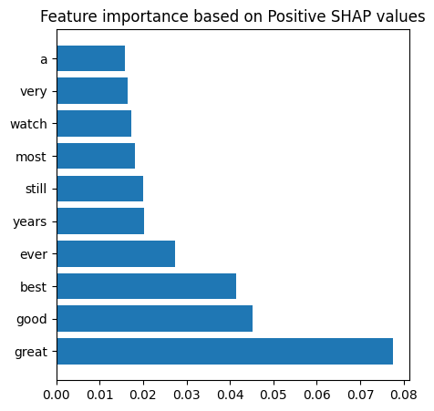

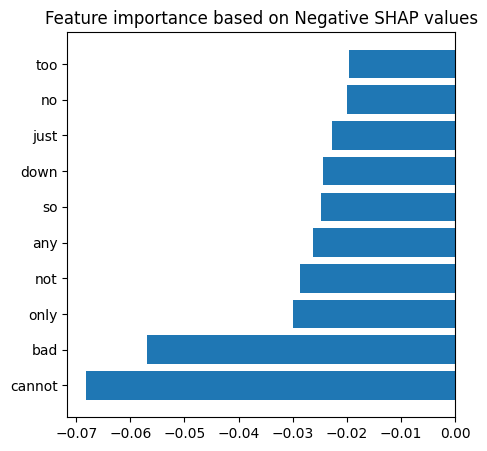

```python
custom_global_explanation(shap_values_bert[:,:,1])
```

# 7 Model Comparision

## DTC vs BERT

```python
dtc_bert_sorted_by_diff.head(5)
```

|  | bert_0 | bert_1 | logreg_0 | logreg_1 | dtc_0 | dtc_1 | label | logreg_dtc_diff | logreg_bert_diff | dtc_bert_diff |
| --- | --- | --- | --- | --- | --- | --- | --- | --- | --- | --- |
| 11488 | 0.999520 | 0.000480 | 0.981925 | 0.018075 | 0.0 | 1.0 | 0 | 0.981925 | 0.017595 | 0.999520 |
| 1356 | 0.999511 | 0.000489 | 0.933107 | 0.066893 | 0.0 | 1.0 | 0 | 0.933107 | 0.066405 | 0.999511 |
| 16722 | 0.999500 | 0.000500 | 0.959625 | 0.040375 | 0.0 | 1.0 | 0 | 0.959625 | 0.039875 | 0.999500 |
| 1221 | 0.999491 | 0.000509 | 0.452192 | 0.547808 | 0.0 | 1.0 | 0 | 0.452192 | 0.547299 | 0.999491 |
| 3055 | 0.999489 | 0.000511 | 0.769727 | 0.230273 | 0.0 | 1.0 | 0 | 0.769727 | 0.229762 | 0.999489 |

## logreg vs BERT

```python
logreg_bert_sorted_by_diff.head(5)
```

|  | bert_0 | bert_1 | logreg_0 | logreg_1 | dtc_0 | dtc_1 | label | logreg_dtc_diff | logreg_bert_diff | dtc_bert_diff |
| --- | --- | --- | --- | --- | --- | --- | --- | --- | --- | --- |
| 7153 | 0.004288 | 0.995712 | 0.943614 | 0.056386 | 0.541667 | 0.458333 | 1 | 0.401947 | 0.939326 | 0.537378 |
| 16340 | 0.998061 | 0.001939 | 0.058830 | 0.941170 | 0.523810 | 0.476190 | 1 | 0.464979 | 0.939231 | 0.474251 |
| 9634 | 0.047879 | 0.952121 | 0.981160 | 0.018840 | 1.000000 | 0.000000 | 1 | 0.018840 | 0.933281 | 0.952121 |
| 20880 | 0.035587 | 0.964413 | 0.960892 | 0.039108 | 1.000000 | 0.000000 | 0 | 0.039108 | 0.925305 | 0.964413 |
| 3836 | 0.998744 | 0.001256 | 0.074979 | 0.925021 | 0.952381 | 0.047619 | 0 | 0.877402 | 0.923765 | 0.046363 |